# 1. Data warehouse:

# 4. Statistical analysis:

- Is there any significant difference between Funds raised by companies that are still operating vs companies that closed down? Write the null hypothesis and alternative hypothesis. Test for significance and conclusion

```python
#H0(Null Hypothesis) = There is no difference between funds raised by companies that are still operating vs companies that closed down
#HA(Alternate Hypothesis) = There is significant difference between funds raised by companies that are still operating vs companies that closed down
#Two sample independent T test can be used for this
funds_operating = df[df['OperatingState']=='Operating']['FundingNum']
funds_closed = df[df['OperatingState']=='Closed']['FundingNum']
from scipy.stats import ttest_ind
t_statistic, p_value = ttest_ind(funds_operating, funds_closed)
print(t_statistic, p_value)
if p_value < 0.05:    # alpha value is 0.05 or 5%
   print(" We are rejecting null hypothesis. That is, we can say that there is significant difference between funds raised by companies that are still operating vs companies that closed down ")
else:
  print("We fail to reject the null hypothesis. That is, we cannot say that there is significant difference between funds raised by companies that are still operating vs companies that closed down")
```

```
1.3039133074374796 0.19317471078450296
We fail to reject the null hypothesis. That is, we cannot say that there is significant difference between funds raised by companies that are still operating vs companies that closed down
```

- Make a copy of the original data frame.

```python
dfo = pd.read_csv('DS+-+Part3+-+CompanyX_EU.csv') #importing the csv file as a Pandas data frame
dfcop = dfo.copy() #making a copy of the dataframe
dfcop.info()
```

```
<class 'pandas.core.frame.DataFrame'>
RangeIndex: 662 entries, 0 to 661
Data columns (total 6 columns):
 #   Column          Non-Null Count  Dtype
---  ------          --------------  -----
 0   Startup         662 non-null    object
 1   Product         656 non-null    object
 2   Funding         448 non-null    object
 3   Event           662 non-null    object
 4   Result          662 non-null    object
 5   OperatingState  662 non-null    object
dtypes: object(6)
memory usage: 31.2+ KB
```

- Check frequency distribution of outcome variable

```python
df['Result'].value_counts() #Showing the frequency of outcomes using frequency table
#Insight - There are high number of contestants when compared to winners which points to the competitiveness off the events and high merit of the winner title
```

```
Contestant         282
Finalist            52
Audience choice     20
Winner              17
Runner up           15
Name: Result, dtype: int64
```

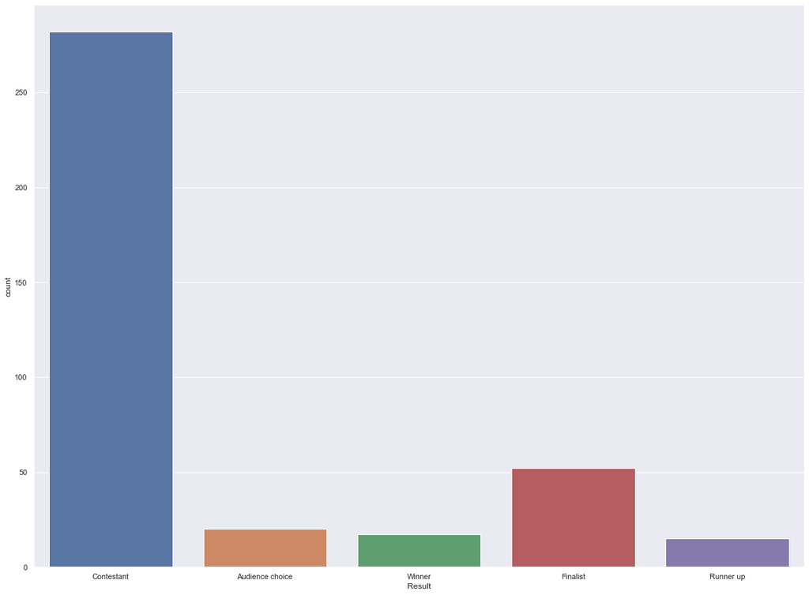

```python
sns.countplot(df['Result']) #Showing the frequency of outcomes using count plot
```

- Calculate percentage of winners that are still operating and percentage of contestants that are still operating

```
Winners Count= 17 Winners Operating Count= 12 Contestant count= 282 contestant operating count= 194
percentage of winners that are still operating= 70.5882
percentage of contestants that are still operating= 68.7943
```

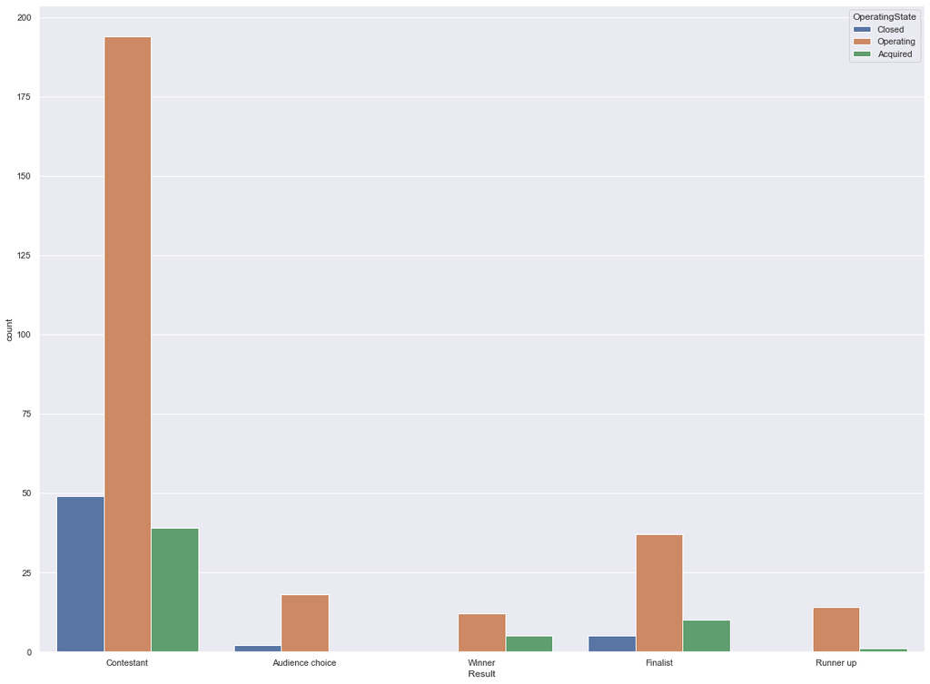

```python
dfw = df[df['Result']=='Winner'] #filtering winners and saving it as a dataframe
dfc = df[df['Result']=='Contestant'] # filtering contestants and saving it as a dataframe
winners_count = dfw.shape[0]
contestant_count = dfc.shape[0]
dfow = dfw[dfw['OperatingState']=='Operating']
dfoc = dfc[dfc['OperatingState']=='Operating']
operating_winners_count = dfow.shape[0]
operating_contestant_count = dfoc.shape[0]
print('Winners Count=',winners_count, 'Winners Operating Count=',operating_winners_count, 'Contestant count=', contestant_count, 'contestant operating count=', operating_contestant_count)
print('percentage of winners that are still operating=', round(operating_winners_count/winners_count*100, 4))
print('percentage of contestants that are still operating=', round(operating_contestant_count/contestant_count*100, 4))
sns.countplot(df['Result'], hue=df['OperatingState'])
```

# Write your hypothesis comparing the proportion of companies that are operating between winners and contestants:

- Write the null hypothesis and alternative hypothesis.
- Test for significance and conclusion

```python
#H0(Null Hypothesis): The proportions of companies that are operating between winners and contestants are the same
#HA (Alternate Hypothesis): The proportions of companies that are operating between winners and contestants are significantly different
#Proportions_Ztest can be used to test the significance in difference
from statsmodels.stats.proportion import proportions_ztest

stat, pval = proportions_ztest([operating_winners_count, operating_contestant_count] , [winners_count, contestant_count])

if pval < 0.05:
    print(f'With a p-value of {round(pval,4)}, the difference in proportions is significant.That is, we reject the null hypothesis')
else:
    print(f'With a p-value of {round(pval,4)}, the difference in proportions is not significant.That is, we fail to reject the null hypothesis')
```

```
With a p-value of 0.8767, the difference in proportions is not significant.That is, we fail to reject the null hypothesis
```

```python
#Insights:
#There doesn't seem to be any significant difference between the outcome of winners and contestants based on this hypothesis testing
#But as can be seen from the count plot above, it is due to the fact that among the winners, all the startups that are outside of the operating category are actually acquired and not closed
#where as, among the contestants, there is a  considerable number of startups that have closed
#Hence to properly predict the success or failure of startups based on their performance in events, the count of acquired companies needs to be treated differently compared to the count of closed ones which is not done here
```

- Check distribution of the Event variable.

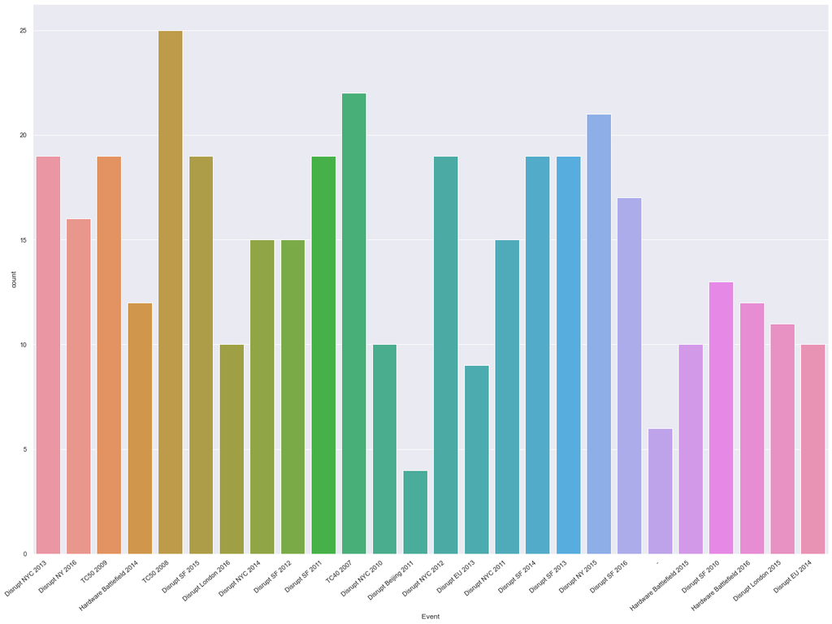

```python
#Plotting the count of companies across each event
ax = sns.countplot(x="Event", data=df)

ax.set_xticklabels(ax.get_xticklabels(), rotation=40, ha="right") #Rotating the labels to make it readable
plt.tight_layout()
plt.show()
```

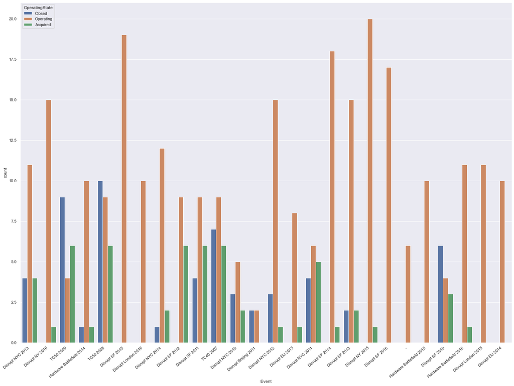

```python
#Plotting the distribution of operating state of the companies participating in each event
ax1 = sns.countplot(df['Event'], hue=df['OperatingState'])
ax1.set_xticklabels(ax.get_xticklabels(), rotation=40, ha="right") #Rotating the labels to make it readable
plt.tight_layout()
plt.show()
```

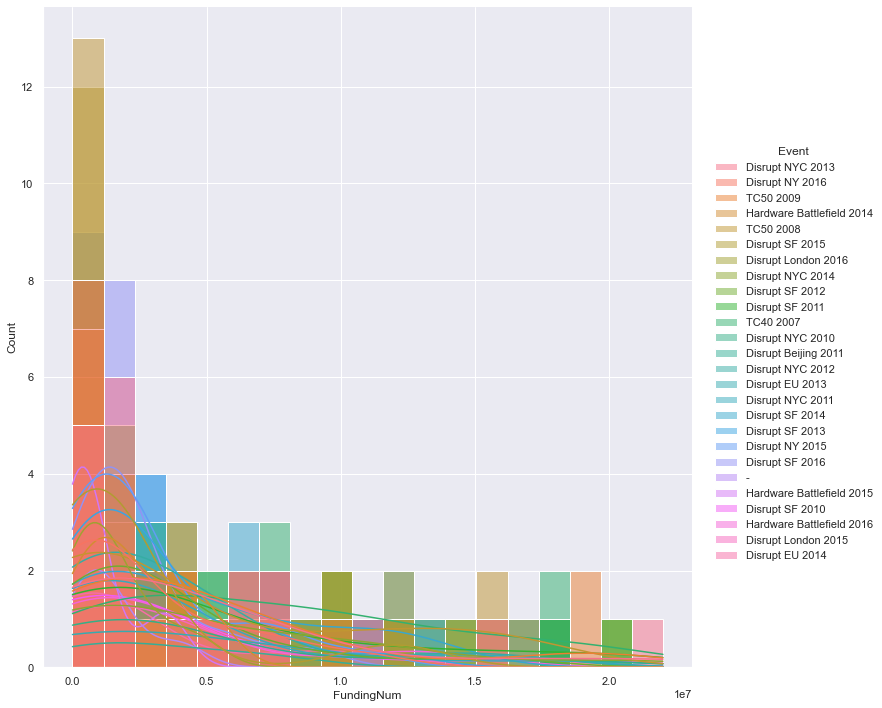

```python
#Plotting the distribution of funds of companies across the events they participated in
sns.displot(data=df, x='FundingNum', hue='Event', kde=True, height=10, aspect=1)
```

```python
#Insights:
#A significant proportion of companies that participated in the events TC50 2008, TC502009 & TC40 2007 have closed
#Hence we may say that a significant number of companies that participated in old events or possibly old companies (from years 2007-2009) have closed
#Funds of companies seem to vary as per the events they participated in
#But it should be due to the difference in the number of participants in each event (ranges from 4 to 25)
#For example, the participants of TC50 2008 which had a high count in previous plot also have high funding in this plot
```

- Select only the Event that has disrupt keyword from 2013 onwards.

```python
#Selecting all records with disrupt keyword and having years from 2013
df[(df['Event'].str.contains('Disrupt'))&((df['Event'].str.endswith("2013"))|(df['Event'].str.endswith('2014'))|(df['Event'].str.endswith('2015'))|(df['Event'].str.endswith('2016')))]['Event']
```

```
1         Disrupt NYC 2013
3          Disrupt NY 2016
13         Disrupt SF 2015
14     Disrupt London 2016
16         Disrupt SF 2015
              ...
635        Disrupt NY 2015
641       Disrupt NYC 2013
642        Disrupt SF 2014
646    Disrupt London 2015
660        Disrupt SF 2013
Name: Event, Length: 185, dtype: object
```

```python
#Displaying only the unique events
df[(df['Event'].str.contains('Disrupt'))&((df['Event'].str.endswith("2013"))|(df['Event'].str.endswith('2014'))|(df['Event'].str.endswith('2015'))|(df['Event'].str.endswith('2016')))]['Event'].unique()
```

```
array(['Disrupt NYC 2013', 'Disrupt NY 2016', 'Disrupt SF 2015',
       'Disrupt London 2016', 'Disrupt NYC 2014', 'Disrupt EU 2013',
       'Disrupt SF 2014', 'Disrupt SF 2013', 'Disrupt NY 2015',
       'Disrupt SF 2016', 'Disrupt London 2015', 'Disrupt EU 2014'],
      dtype=object)
```

- Write and perform your hypothesis along with significance test comparing the funds raised by companies across NY, SF and EU events from 2013 onwards.

```python
#H0(Null Hypothesis): Funds raised by companies across NY, SF and EU events from 2013 onwards are the same
#HA (Alternate Hypothesis): The funds raised by companies across at least any one of NY, SF and EU events from 2013 onwards is significantly different from the others
#We can do One way Annova  test for this hypothesis testing
#We assume that NY does not include NYC, hence we include the condition df['Event'].str.contains('NYC')==False below to exclude NYC
Funds_NY = df[(df['Event'].str.contains('NY'))&(df['Event'].str.contains('NYC')==False)&((df['Event'].str.endswith("2013"))|(df['Event'].str.endswith('2014'))|(df['Event'].str.endswith('2015'))|(df['Event'].str.endswith('2016')))]['FundingNum']
Funds_SF = df[(df['Event'].str.contains('SF'))&((df['Event'].str.endswith("2013"))|(df['Event'].str.endswith('2014'))|(df['Event'].str.endswith('2015'))|(df['Event'].str.endswith('2016')))]['FundingNum']
Funds_EU = df[(df['Event'].str.contains('EU'))&((df['Event'].str.endswith("2013"))|(df['Event'].str.endswith('2014'))|(df['Event'].str.endswith('2015'))|(df['Event'].str.endswith('2016')))]['FundingNum']

from scipy import stats
f , p_value = stats.f_oneway(Funds_NY,Funds_SF,Funds_EU)
print('P Value', p_value)
if p_value < 0.05 :
  print("Reject the Null hypothesis i.e. The funds raised by companies across at least any one of NY, SF and EU events from 2013 onwards is significantly different from the others")
else:
  print("Fail to reject Null hypothesis i.e.There is no significant difference between funds raised by companies across NY, SF and EU events from 2013 onwards")
```

```
P Value 0.6328267301763726
Fail to reject Null hypothesis i.e.There is no significant difference between funds raised by companies across NY, SF and EU events from 2013 onwards
```

- Plot the distribution plot comparing the 3 city events

```python
df['EventCity']=df['Event'].copy() #Making a copy of 'Event' column and saving it as 'EventCity' column
#In the following statements, we poplulate the EventCity column with the values 'NY' or 'SF' or 'EU' by filtering the records with the respective state and years from 2013
df.loc[(df['EventCity'].str.contains('NY'))&(df['EventCity'].str.contains('NYC')==False)&((df['EventCity'].str.endswith("2013"))|(df['EventCity'].str.endswith('2014'))|(df['EventCity'].str.endswith('2015'))|(df['EventCity'].str.endswith('2016'))),'EventCity']= 'NY'
df.loc[(df['EventCity'].str.contains('SF'))&((df['EventCity'].str.endswith("2013"))|(df['EventCity'].str.endswith('2014'))|(df['EventCity'].str.endswith('2015'))|(df['EventCity'].str.endswith('2016'))),'EventCity']= 'SF'
df.loc[(df['EventCity'].str.contains('EU'))&((df['EventCity'].str.endswith("2013"))|(df['EventCity'].str.endswith('2014'))|(df['EventCity'].str.endswith('2015'))|(df['EventCity'].str.endswith('2016'))),'EventCity']= 'EU'
#Creating a new dataframe with only the records that have 'NY' or 'SF' or 'EU' in the 'EventState' column
dfes = df[(df['EventCity']=='NY')|(df['EventCity']=='SF')|(df['EventCity']=='EU')]
dfes
```

|  | Startup | Product | Funding | Event | Result | OperatingState | FundingNum | EventCity |
| --- | --- | --- | --- | --- | --- | --- | --- | --- |
| 3 | 3Dprintler | 3dprintler.com | $1M | Disrupt NY 2016 | Audience choice | Operating | 1000000 | NY |
| 13 | Agrilyst | agrilyst.com | $1M | Disrupt SF 2015 | Winner | Operating | 1000000 | SF |
| 16 | Aircall | aircall.io | $11.6M | Disrupt SF 2015 | Contestant | Operating | 11600000 | SF |
| 42 | asap54.com | asap54.com | $8.3M | Disrupt EU 2013 | Runner up | Operating | 8300000 | EU |
| 46 | Ava | avawomen.com | $12.3M | Disrupt SF 2015 | Contestant | Operating | 12300000 | SF |
| ... | ... | ... | ... | ... | ... | ... | ... | ... |
| 633 | Wellth | wellthapp.com | $2.5M | Disrupt NY 2015 | Contestant | Operating | 2500000 | NY |
| 634 | Wellthy | wellthy.com | $2M | Disrupt SF 2015 | Contestant | Operating | 2000000 | SF |
| 635 | Welltwigs | welltwigs.com | $50K | Disrupt NY 2015 | Contestant | Operating | 50000 | NY |
| 642 | Xendo | xendo.com | $28K | Disrupt SF 2014 | Contestant | Acquired | 28000 | SF |
| 660 | Zula | zulaapp.com | $3.4M | Disrupt SF 2013 | Audience choice | Operating | 3400000 | SF |

130 rows × 8 columns

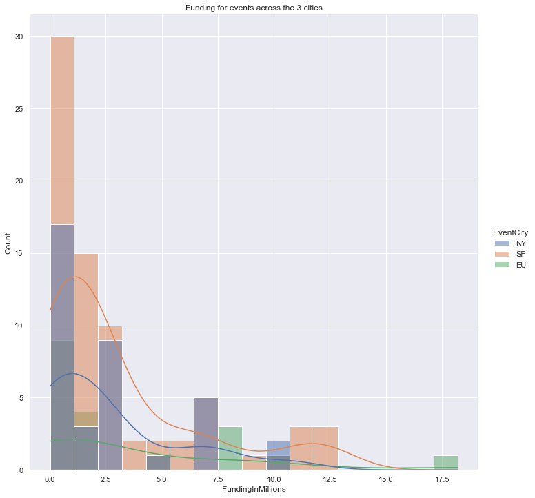

```python
#Distribution plot of funding for events across the 3 cities
dfes['FundingInMillions'] = dfes['FundingNum']/1000000 #Creating a new column with funding in millions
sns.displot(x ='FundingInMillions', hue ='EventCity', data = dfes, kde=True, height=10, aspect=1).set(title='Funding for events across the 3 cities')
```

```
[Text(0.5, 1.0, 'Funding for events across the 3 cities')]
```

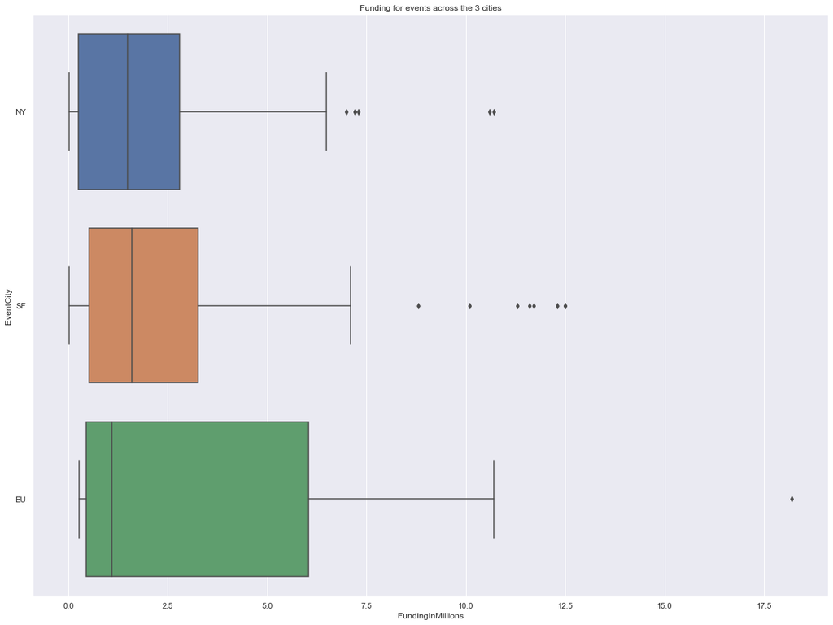

```python
#Showing distribution of funding for events across the 3 cities using box plot
sns.boxplot(x ='FundingInMillions', y ='EventCity', data = dfes).set(title='Funding for events across the 3 cities')
```

[output not shown]

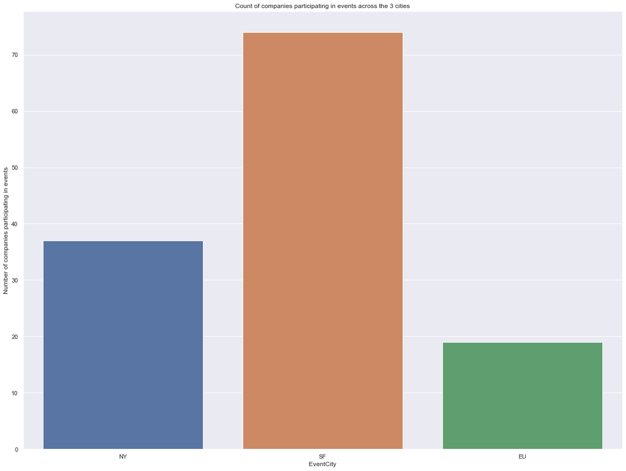

```python
#Plotting the count of companies participating in events across the 3 cities
sns.countplot(dfes['EventCity']).set(ylabel='Number of companies participating in events', title='Count of companies participating in events across the 3 cities')
```

```
[Text(0, 0.5, 'Number of companies participating in events'),
```

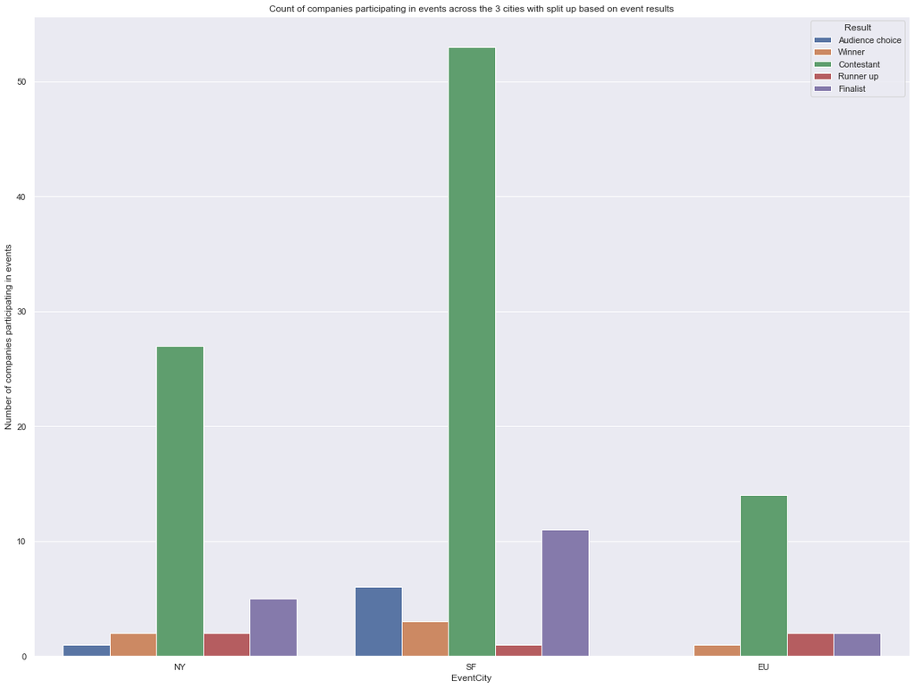

```python
#Plotting the count of companies participating in events across the 3 cities with the event outcomes shown in different colours
sns.countplot(dfes['EventCity'], hue=dfes['Result']).set(ylabel='Number of companies participating in events', title='Count of companies participating in events across the 3 cities with split up based on event results')
```

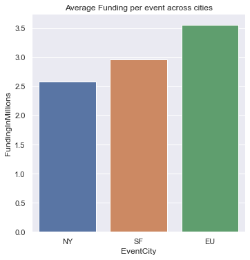

```python
#Plotting average funding per event for the 3 cities
dfes['FundingInMillions'] = dfes['FundingNum']/1000000 #Creating a new column with funding in millions
sns.catplot(x='EventCity', y='FundingInMillions', data=dfes, kind='bar', ci=None).set(title = 'Average Funding per event across cities')
```

[output not shown]

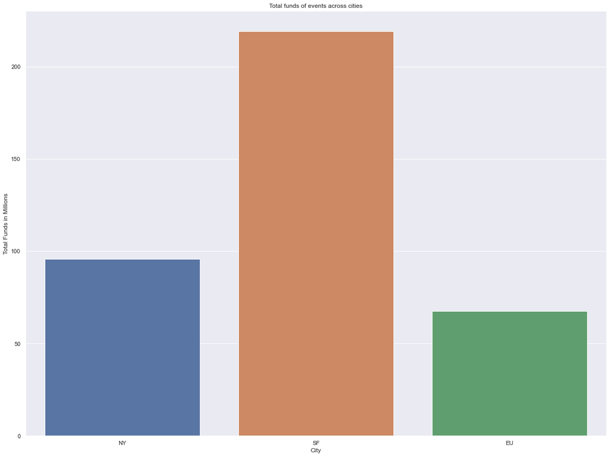

```python
#Plotting total funds for the events across the 3 cities
CitySum = [['NY', dfes[dfes['EventCity']=='NY']['FundingInMillions'].sum()],['SF', dfes[dfes['EventCity']=='SF']['FundingInMillions'].sum()], ['EU', dfes[dfes['EventCity']=='EU']['FundingInMillions'].sum()]]
dfsum = pd.DataFrame(CitySum, columns=['City', 'TotalFunds'])
sns.barplot(x=dfsum['City'], y=dfsum['TotalFunds']).set(title='Total funds of events across cities', ylabel='Total Funds in Millions')
```

```python
#Insights:
#SF City events have highest participants followed by NY and then by EU as can be seen from the count plot
#The average funding per startup is the highest for EU follwed by SF and then NY
#EU's high average funding could be attributed that one outlier with around 18 million in funds that can be seen clearly in the boxplot
#EU's relatively low median as seen in the box plots also supports the above insight about outlier
#The total funding is the highest for SF followed by NY and then EU, but this should just be a consequence of the number of participants being in the same order as described in the first point
#There is no significant pattern in the number of winners across each city. It also variees as per the event participant count in each city.
```

# 5. Write your observations on improvements or suggestions on quality, quantity, variety, velocity, veracity etc. on the data points collected to perform a better data analysis.

- More kinds of data on each startup like net worth, profitability metrics etc. if gathered would help in providing more insights
- The format of data gathered in Funding column could have been more conventional (like numeric format or other formats that can be easily converted to numeric)
- The high number of missing values in Funding column and few in Product column makes the dataset seem incomplete
- Some of the categories under the Result column don't seem to be well separated from each other. Example: 'Finalist' and 'Runner up' seem to overlap with each other.